# Exploring the BRFSS data

## Setup

### Load packages

```r
library(ggplot2)
library(dplyr)
```

### Load data

```r
load("brfss2013.RData")
```

## Part 1: Data

### What is this data about?

- In 1984 the Center for Disease control (CDC) started a *survey* which is state-based in the US.
- The *survey* is called **Behavioral Risk Factor Surveillance System** (BRFSS)
- The survey is conducted via landline and cellular telephones.
- The survey uses a standardized questionnaire.
- The survey is used to collect data among the US population regarding their: risk behavious and preventive health practices that can affect their health status.

### Structure of the survey?

- **Standard Core Questions:** Questions that are asked by every state across the US.
- **Rotating Core Questions:** Questions that are asked by all states on an alternate year basis.
- **Optional Questions:** Optional questions from a standardized set of questions that each state can choose from to include in it’s questionnaire.
- **State-added Questions:** State specific questions that are not common across all the states but specific to that particular state asking them.

### How to ensure survey is uniform across all of the US?

In order to ensure uniformity of the survey across all of the US. BRFSS has certain standards that are followed:

- All states ask the **Standard Core Questions** without modification. This ensures uniform data observation from the survey. Addition of the **Optional Questions** and **State-added Questions** is left to the state.
- unobrusive electonic monitoring of the interviewers is also done across all states. To ensure uniformity of survey taking across all the states.
- Clear definition of what constitutes a unit from which the survey is taken: Household.

### What sampling approach is used in selecting candidates for the survey?

- The survey is conducted in all states across the US. In this way it covers the whole of the US population in all the states and terrotories. (DC and GUAM, Porto Rico including)
- Sampling style used is Stratified Sampling: Each state decides to stratify based on any of the following ways: county, public-health district or other sub-geography.
- Inside each Strata, further Stratified Sampling is done based on households with Landlines , household with Cell phones.
- Landlines: Disproportionalte staritified Sampling (DSS) is applied by splitting data into regions with high density landlines vs those with min-density landlines. A ratio of 1:1.5 is followed to ensure, equal representation from regions with mid-density landlines. Further more inside each of the sampled households, one of the occupants of the household is randomly selected, with each occupant of the household having an equally likely chance of getting selected for the survey.
- Therefore at the topmost level we have stratified sampling, with each strata further subjected to stratified sampling, finally simple random sampling is used at the lowermost level to select the subject to be surveyed.
- Cell phones: Every cell phone is considered an indivdual single owner household. And random samples are drawn from a list of cell numbers, where each cell number has an equal likelihood of being sampled.

### **Answer :**

- **Generalizability** : Since the data is collected using a survey of randomly selected individuals from stratified sample across the US. We can safely say the survey is generalizable **only** across the US population.
- **Causality** : The survey is **NOT** useful for causality. As we have not randomly selected and randomly assigned individuals into experimental groups to draw any causual relationships among the variable of the data in which we seek to establish causality.
- **Potential biases**: There is a chance of bias , due to non-participation of randomly selected individuals. Volunteer bias due to certain segments of individuals in each strata more willing to partiipate than other individuals.

In conclusion the survey is **Generalizable** across the US. Any patterns we observe are **Associative** and we need further controlled experiments to establish **Causality**. There is a possibility of **Participation bias** as well as **Non-response** bias to be introduced into the survey.

## Part 2: Research questions

#### **Research question 1:**

*Which has a stronger association with General Health, Income or Exercise?*

- I am interested in seeing if any associative relationship exists between income and health, versus exercise and health.
- This question is of interest to me because. Not everyone is rich and can have access to better healthcare.
- But everyone can exercise to stay fit.
- So it will be intersting to see which has a more stronger associative relationship leading to better health if any.

#### **Research question 2:**

*Is there any association between BMI and States ?*

- I am interested in finding out, it all States in the US have equal distribution of BMI or it there are any interesting patterns in the data to be observed.
- This is important because BMI is an excellent indicator of a State’s health metric.
- States with people in the Obese and Overweight BMI range are overall in an unhealthy category.

#### **Research question 3:**

*Is there an association between Income and Depression ?*

- I am interested in seeing if better income has any association with Depression.
- I find this question really interesting as many rich and famous people commit suicide.
- So this has made me curious, was there any association with high income that leads to these suicides.
- This EDA will seek to see if the above line of thinking has any association or no association

## Part 3: Exploratory data analysis

### **Research question 1:**

### *Which has a stronger association with General Health, Income or Exercise?*

### **Step1 : Load and Clean up Data for analysis**

we begin by loading the required libraries; and loading the dataset into memory

```r
library(ggplot2)
library(dplyr)
library(gridExtra)
library(forcats)

load("brfss2013.RData")
```

We then select the variables of interest: genhlth(Ordinal), income2(Oridnal), exerany2(categorical)  
Here we have: 2 Ordinal Variables and 1 categorical variable for doing our analysis.

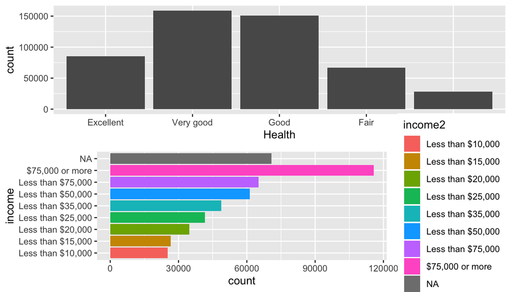

```r
analysis1 <- brfss2013%>%select(c("genhlth","income2","exerany2"))%>%filter(!is.na(genhlth) )
plothealth <- ggplot(analysis1, aes(x=genhlth))+geom_bar()+xlab("Health")
plotincome <- ggplot(analysis1, aes(fill = income2,x = income2))+geom_bar(position = "stack")+coord_flip()+xlab("income")
grid.arrange(plothealth,plotincome,nrow = 2)
```

We see a quick plot of General health distribution and also income levels.

```r
analysis1$income2 <- fct_explicit_na(analysis1$income2, na_level = "NotDisclosed")
analysis1%>%group_by(income2)%>%summarise(countgp = n(), total = length(analysis1$income2), percentage = (countgp/total)*100 )
```

```
## # A tibble: 9 x 4
##   income2           countgp  total percentage
##   <fct>               <int>  <int>      <dbl>
## 1 Less than $10,000   25252 489790       5.16
## 2 Less than $15,000   26633 489790       5.44
## 3 Less than $20,000   34705 489790       7.09
## 4 Less than $25,000   41563 489790       8.49
## 5 Less than $35,000   48687 489790       9.94
## 6 Less than $50,000   61319 489790      12.5
## 7 Less than $75,000   65102 489790      13.3
## 8 $75,000 or more    115659 489790      23.6
## 9 NotDisclosed        70870 489790      14.5
```

We see that there is a huge chunk of NotDisclosed **14.46%** , which is one of the levels in the income category. As a result we cannot drop it. But we will keep it as a separate category of it’s own.

We will now analyze exercise to see if any NAs can be dropped

```r
analysis1$exerany2 <- as.character(analysis1$exerany2)
analysis1$exerany2[is.na(analysis1$exerany2)] <- "NotDisclosed"
analysis1$exerany2 <- as.factor(analysis1$exerany2)
plotexercis <- ggplot(analysis1, aes(fill = exerany2,x=exerany2))+geom_bar()
analysis1%>%group_by(exerany2)%>%summarise(countgp = n(), total = length(analysis1$exerany2), percentage = (countgp/total)*100 )
```

```
## # A tibble: 3 x 4
##   exerany2     countgp  total percentage
##   <fct>          <int>  <int>      <dbl>
## 1 No            124561 489790      25.4
## 2 NotDisclosed   33840 489790       6.91
## 3 Yes           331389 489790      67.7
```

**6 percent** is NotDisclosed for exercise this is a very small number, hence we can drop it from our analysis.

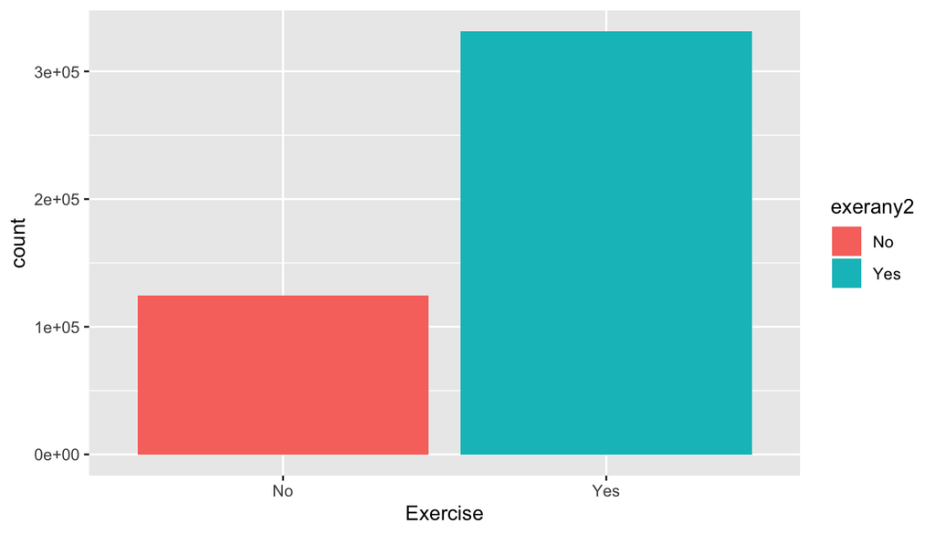

```r
analysis1 <- analysis1%>%select(c("genhlth","income2","exerany2"))%>%filter(!(exerany2 == "NotDisclosed") )
plotexercis <- ggplot(analysis1, aes(fill = exerany2,x=exerany2))+geom_bar(position = "stack")+xlab("Exercise")
grid.arrange(plotexercis,nrow = 1)
```

We now have only Yes and No categories for those who exercise. As we have removed the 6% NotDisclosed category.

### **Step2 : Exploratory Data Analysis among the variables**

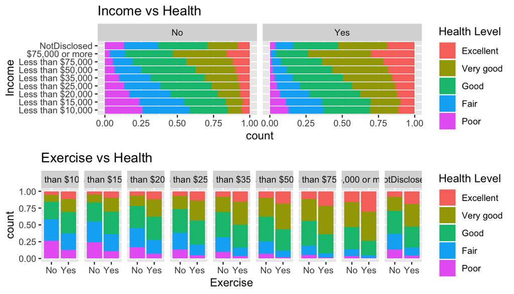

```r
# There seems to be an associative relationship between income and health
plotincomevshealth <- ggplot(analysis1, aes(fill=genhlth, x = income2))+geom_bar(position = "fill")+xlab("Income")

# There is an associative relationship between exercise and health.
plotexercisvshealth <- ggplot(analysis1, aes(fill = genhlth,x=exerany2))+geom_bar(position = "fill")+xlab("Exercise")

# Relationship between income and exercise
plotincomevsexercise<- ggplot(analysis1, aes(fill = exerany2,x=income2))+geom_bar(position = "fill")

#Findings: There is an associative connection between: income&Health, exercise&health, income&exercise.
# Let us see what the relationship between these 3 would be:

p1 <- plotincomevshealth+facet_grid(.~exerany2)+coord_flip()+ggtitle("Income vs Health")+guides(fill=guide_legend(title="Health Level"))
p2 <- plotexercisvshealth+facet_grid(.~income2)+labs("Health")+ggtitle("Exercise vs Health")+guides(fill=guide_legend(title="Health Level"))
grid.arrange(p1,p2, nrow = 2)
```

Line1: Creates and stores of plot of Income Vs Health in the variable : plotincomevshealth  
Line2: Creates and stores a plot of Exercise Vs Health in the variable: plotexercisvshealth  
Line3: Creates and stores a plot of Income Vs Exercise in the variable: plotincomevsexercise  
Line 4: Creates breaks up the plotincomevshealth into 2 grids: Those who exercise vs Those who don’t. This enables us to not only view any trends based on income but also trends based on exercise  
Line 5: Breaks up plotexercisevshealth on the basis of income. This enables us to see more clearly the impact of exercise on health, across all income categories.

### **Findings:**

- **Warning** : Association is not Causation.
- From Plot: *(Income vs Health)* it can be seen there is an associative relationship between income and health and exericse.
- As income increases, there is a marked positive increase in health.
- A interesting observation is: With exercise, there is a greater increase in health benefits. This can be seen from Plot: *(Exercise vs Health)* by the steep difference between those who exercise(Yes) versus those who don’t(No), even within same income categories.
- **Therefore, Exercise has a bigger impact on health, compared to income** , the relationship is purely correlational, we need further experiment to formally establish causality.

### **Research question 2:**

### *Is there any association between BMI and States ?*

### **Step1 : Load and Clean up Data for analysis**

We select the variables of interest: weight, height, marital, X_State and income

```r
frameofinterest <- brfss2013%>%select(c("weight2","height3","marital","X_state","income2"))
frameofinterest$marital <- fct_explicit_na(frameofinterest$marital, na_level = "NotDisclosed")
frameofinterest%>%group_by(marital)%>%summarise(countgp = n(), total = length(frameofinterest$marital), percentage = (countgp/total)*100 )
```

```
## # A tibble: 7 x 4
##   marital                         countgp  total percentage
##   <fct>                             <int>  <int>      <dbl>
## 1 Married                          253329 491775     51.5
## 2 Divorced                          70376 491775     14.3
## 3 Widowed                           65745 491775     13.4
## 4 Separated                         10662 491775      2.17
## 5 Never married                     75070 491775     15.3
## 6 A member of an unmarried couple   13173 491775      2.68
## 7 NotDisclosed                       3420 491775      0.695
```

We then plot out a contigency table that shows the percentage distribution of marital status broken down by categories.  
We look at the table to see if we can drop any NotDisclosed.

We find that there are very little NotDisclosed around **0.7 %** so we drop them from the marital, category.

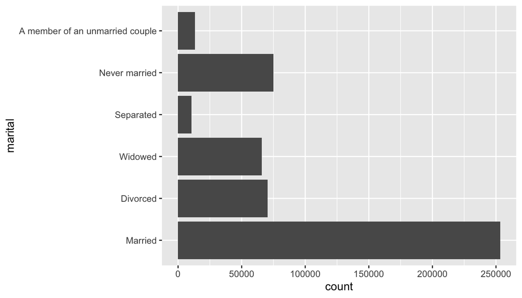

```r
frameofinterest <- frameofinterest%>%select(c("weight2","height3","marital","X_state","income2"))%>%filter(!(marital == "NotDisclosed"))
ggplot(frameofinterest, aes(x=marital))+geom_bar()+coord_flip()
```

### **Step2 : Calculate BMI using: Height, Weight variables**

```r
sum(is.na(frameofinterest$weight2)) # no NAS
```

```
## [1] 0
```

```r
sum(is.na(frameofinterest$height3)) # 6670 / 488355 NAS is roughly only 1.3% so we can drop those rows.
```

```
## [1] 6670
```

```r
unique(frameofinterest$height3)
```

```
##   [1]  507  510  504  600  503  500  505  602  601  506  502  508  501  511   NA
##  [16]  509  606  410  603  604  406  411  408  402  409  605  407  607  400  401
##  [31]  403  608  610 9160  609  306 9205 9125 9171 9105 9150 9167 9162 9120 9173
##  [46] 9164  700 9158 9140 9183 9166  405 9157 9152 9165 9185 9153 9186 9159 9175
##  [61] 9110  304  300 9168 9156  309  404  311 9155 9174  611 9178 9169 9180 9170
##  [76] 9172 9145 9190 9163 9184 9187 9179 9176 9154 9132 9104 9148 9177 9116 9151
##  [91] 9107  702 9130 9135 9103  703 9200 9114 9182 9189 9181 9074 9195 9071 9161
## [106] 9146 9250 9507  308 9188 9509 9506  701 9017 9194 9504 9502  705 9100  704
## [121]  206 9199 9149 9143 9108 9192 9191  303  310 9106  706 9193  803 9057 9198
## [136] 9134 9117  210  301  302  708 9144  305 9102 9147 9124 9201 9211 9206 9210
## [151]  707 9208  709
```

```r
length(frameofinterest$height3)
```

```
## [1] 488355
```

```r
# We see the strange values starting with 9 are values entered in cms, with 9 to indicate that fact: 9 followed bt cm value.

# we find these values are only 0.3 percent of our reading, so we drop them, instead of spending time processing them.

#Convert Feet to inches
frameofinterest <- frameofinterest%>%select(c("weight2","height3","marital","X_state","income2"))%>%filter(!is.na(height3))%>%filter(height3 >= 200, height3 <= 711)%>%
  mutate(inches = height3/100)%>%mutate(inches = gsub("0","",inches))%>%mutate(inches = as.double(inches))%>%mutate(inches = inches*12)

# Now we have values strictly in feet and inches, we proceed to deal with these now.
frameofinterest <- frameofinterest%>%select(c("weight2","height3","marital","inches","X_state","income2"))%>%mutate(weight2 = as.character(weight2))%>%mutate(weight2 = as.double(weight2))%>%
  mutate(bmi = (703*weight2)/(inches*inches))%>%filter(!is.na(bmi))
#dropping NAs as they constitute only 3.2 percent of the data.

frameofinterest$income2 <- fct_explicit_na(frameofinterest$income2, na_level = "NotDisclosed")

frameofinterest$bmicat <- frameofinterest$bmi
frameofinterest$bmicat[frameofinterest$bmicat < 18.5] <- 0
frameofinterest$bmicat[frameofinterest$bmicat >= 18.5 & frameofinterest$bmicat < 25] <- 1
frameofinterest$bmicat[frameofinterest$bmicat >= 25 & frameofinterest$bmicat < 30] <- 2
frameofinterest$bmicat[frameofinterest$bmicat >= 30] <- 3

frameofinterest$bmicat <- as.character(frameofinterest$bmicat)

frameofinterest$bmicat[frameofinterest$bmicat == "0"] <- "Underweight"
frameofinterest$bmicat[frameofinterest$bmicat == "1"] <- "Normalweight"
frameofinterest$bmicat[frameofinterest$bmicat == "2"] <- "Overweight"
frameofinterest$bmicat[frameofinterest$bmicat == "3"] <- "Obese"
```

We nor proceed to calculate the BMI, by using the : height, and weight variables.

### **Step3 : Exploratory Data Analysis BMI versus States**

- To see if there are any states with BMI getting skewed.We plot the Mean BMI versus the Median BMI.
- This shows us of any potential exceptionl outliers that skew the Mean BMI of a population away from it’s Median BMI.

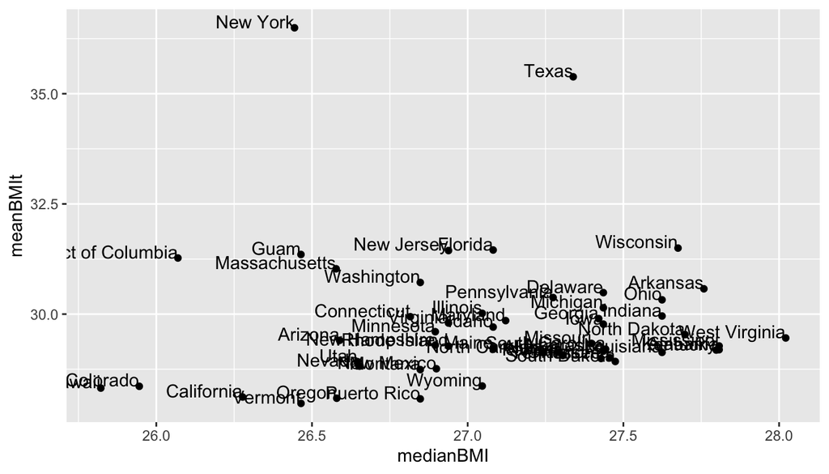

```r
#mean bmi versus median BMi per state
sBMI <- frameofinterest%>%group_by(X_state)%>%summarise(meanBMIt = mean(bmi),medianBMI = median(bmi))
#ggplot(sBMI,aes(x= medianBMI,y=meanBMIt, col=X_state))+geom_point()+facet_wrap(~bmicat)

ggplot(sBMI,aes(x= medianBMI,y=meanBMIt, label=X_state))+geom_point()+geom_text(aes(label=X_state),hjust=1, vjust=0)
```

### **Findings:**

- **Warning** : Association is not Causation.
- From the scatter plot of median(BMI) versus the mean(BMI), it can be seen that there are 2 noticable outlier states: Texas and NewYork.
- For both these states, the Average/Mean BMI is much much larger than the Median BMI value.
- This implies a right skew in the distribution, and there must be some really super obese individuals, in both these states skewing the data to the right.
- We will have to do greater investigation, or track down the really obese individuals and study their circumstances, to see if this is a real problem in Texas and Newyork.

### **Research question 3:**

### *Is there any association between Income and Depression(MentalHealth) ?*

### **Step1 : Load and Clean up Data for analysis**

We load the data , and clean it up, handling any NAs, by refactoring them

```r
analysis3 <- brfss2013%>%select(c("income2","menthlth"))
analysis3$income2 <- fct_explicit_na(analysis3$income2, na_level = "NotDisclosed")
analysis3$menthlth <- as.factor(analysis3$menthlth)
analysis3$menthlth <- fct_explicit_na(analysis3$menthlth, na_level = "Not Shared")
```

We print out a consicse summary table, of what we plan to plot out. We have grouped the days based on income, and this is what will be plotted out

```r
table(analysis3)
```

```
##                    menthlth
## income2                 0     1     2     3     4     5     6     7     8     9
##   Less than $10,000 12587   528  1034   780   423   858   138   556   110    30
##   Less than $15,000 14980   564  1074   759   376   932   139   449   118    24
##   Less than $20,000 21300   858  1535   963   543  1309   152   622   117    16
##   Less than $25,000 26890  1057  1894  1180   590  1450   202   667   107    25
##   Less than $35,000 33295  1407  2355  1360   686  1690   201   663   114    17
##   Less than $50,000 43147  1969  3048  1793   802  2169   186   713   161    21
##   Less than $75,000 46230  2411  3542  1943   921  2386   217   754   138    18
##   $75,000 or more   85280  4640  6408  3316  1513  4064   378  1117   209    25
##   NotDisclosed      50752  1772  2630  1499   806  1796   248   812   170    22
##                    menthlth
## income2                10    11    12    13    14    15    16    17    18    19
##   Less than $10,000   902     7    78     8   289  1072    18    18    22     7
##   Less than $15,000   988     7    87    10   229  1048    18     4    24     5
##   Less than $20,000  1070     7    89    11   284  1140    17    17    17     6
##   Less than $25,000  1190     9    97     7   252  1199    16     9    23     6
##   Less than $35,000  1220    10    87    13   278  1094    12    14    26     4
##   Less than $50,000  1520     7    79    11   249  1260    14     7    18     6
##   Less than $75,000  1507    10    97     4   235  1161    17     8    13     3
##   $75,000 or more    2210     5   107    13   350  1574    22    15    20     4
##   NotDisclosed       1310    12    91    20   350  1362    27    13    18     4
##                    menthlth
## income2                20    21    22    23    24    25    26    27    28    29
##   Less than $10,000   737    61    21     7    20   280    14    29    85    53
##   Less than $15,000   662    60     9     6     7   275     8    16    67    49
##   Less than $20,000   753    50    13     8    15   240     9    21    61    43
##   Less than $25,000   723    67     9     3     8   260    18    21    88    41
##   Less than $35,000   673    54    10     6     5   251    11    19    63    49
##   Less than $50,000   742    54     9     5    14   236     7    15    80    39
##   Less than $75,000   671    38    13     7     7   223     6    14    68    43
##   $75,000 or more     910    50    16     6     3   271     6    10    76    58
##   NotDisclosed        762    63    13    13     8   282    10    19    92    40
##                    menthlth
## income2                30   247  5000 Not Shared
##   Less than $10,000  3836     0     0        833
##   Less than $15,000  3070     1     0        729
##   Less than $20,000  2833     0     0        754
##   Less than $25,000  2837     0     0        787
##   Less than $35,000  2429     0     0        751
##   Less than $50,000  2431     0     0        697
##   Less than $75,000  1996     0     0        530
##   $75,000 or more    2421     0     0        805
##   NotDisclosed       3668     0     1       2741
```

### **Step2 : Exploratory Data Analysis between income and Depression**

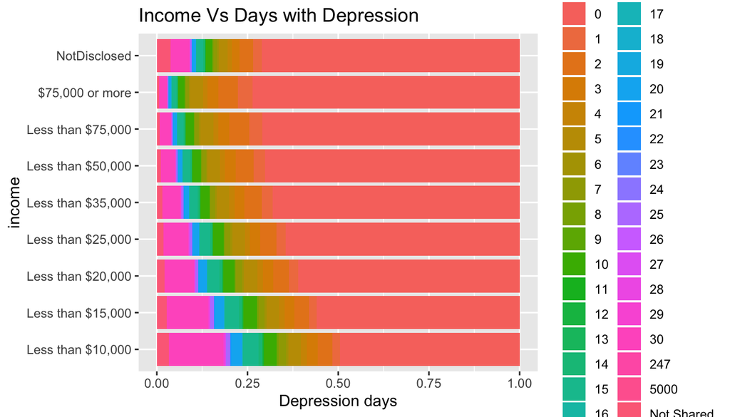

```r
ggplot(analysis3, aes(fill = menthlth,x=income2))+geom_bar(position = "fill")+coord_flip()+ggtitle("Income Vs Days with Depression")+xlab("income")+ylab("Depression days")+guides(fill=guide_legend(title="Days"))
```

We plot the income slabs versus number of days people suffer from poor mental health/Depression. Our findings indicate a trend.

### **Findings :**

- **Warning** : Association is not Causation.
- It can be seen that as income and depression have a reverse association. The richer a person, the less depression.
- We were trying to answer questions as to why the rich and famous commit suicide, but it looks like the general trend suggests that more money means a better state of mental/depression free life.
- Celebrities maybe outliers. Who cannot be accounted for by this plot.